# CS Student Survey

Michał Wyrwa

2019-10-12

# Details about the survey

This page presents results from survey on academic and work-related expectations of first-year students of cognitive science (CS). Data was collected in early October 2019 at Adam Mickiewicz University in Poznań.

Survey was handed out to students during the Introduction to Cognitive Science class in the first week of the academic year. Students were informed that participating is optional and that it will not influence their grades. They were also informed that they do not have to sign using their real names. Because the surveys are going to be handed back to students at the end of the winter term, they were encouraged to sign in a way that would allow them to identify their survey later on.

There were 3 questions:

1. Co rozumiesz pod pojęciem kognitywistyki? [How do you define cognitive science?]
2. Jakie masz oczekiwania względem wybranego kierunku studiów? Od czego zależy, czy te oczekiwania się spełnią? [Given studies you chose, what are your expectations? What will decide if they are met?]
3. Kim chcesz zostać? [Who do you want to become?]

The responses on the second question are divided into two separate categories: expectations and requirements.

Data was tagged by hand.

# Results

## What is cognitive science?

New students know what cognitive science in a wide sense is: a science about cognition, mind and brain. They differ, however, in their understanding of CS structure. Associating CS with psychology, for example, is almost as frequent as stating that the cognitive science is interdisciplinary. All remaining disciplines—biology, philosophy, artifical intelligence research—are relatively rarely mentioned. This suggest that first year students are in most part unaware of the interdisciplinary nature of cognitive science. For convenience, labels used by students to define CS are presented both as a wordcloud in Figure 1 and in Table 1 below.

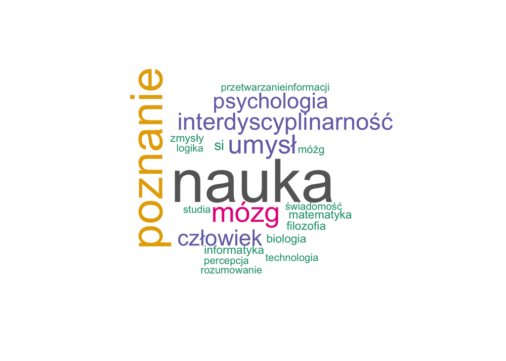

Figure 1: Word cloud of the most common ways of defining CS among first year students.

Table 1: Frequency of labels used to define CS.

| Label | Frequency |
| --- | --- |
| nauka | 81 |
| poznanie | 57 |
| mózg | 31 |
| umysł | 28 |
| interdyscyplinarność | 24 |
| człowiek | 22 |
| psychologia | 21 |
| si | 9 |
| biologia | 5 |
| filozofia | 5 |
| informatyka | 5 |
| matematyka | 5 |
| móżg | 4 |
| zmysły | 4 |
| logika | 3 |
| percepcja | 3 |
| przetwarzanieinformacji | 3 |
| rozumowanie | 3 |
| studia | 3 |

| Label | Frequency |
| --- | --- |
| świadomość | 3 |
| technologia | 3 |
| emocje | 2 |
| lingwistyka | 2 |
| neurobiologia | 2 |
| antropologia | 1 |
| epistemologia | 1 |
| humanistyka | 1 |
| inteligencja | 1 |
| modelowanie | 1 |
| multidyscyplinarność | 1 |
| myślenie | 1 |
| neuronauka | 1 |
| offtopic | 1 |
| poercepcja | 1 |
| praktyka | 1 |
| scifi | 1 |
| uczenie | 1 |
| zachowanie | 1 |

## What are your expectations?

Expectations grouped into categories are presented in Table 2. For almost all students, studying has an epistemic end goal, i.e., they want to gain knowledge. Surprisingly less people chose to study CS to help themselves find a job then to find and/or develop their passions. This indicate that the motivation for choosing CS are not monetary or career-related. Moreover, together with the modest number of any other expectations, results suggest that the issue in question is not thought through by young people. Full list of expectations is presented in Table 3.

Table 2: Top level expectations first year students have, related to studying cognitive science.

| Expectation | Frequency |
| --- | --- |
| wiedza | 73 |
| pasja | 15 |
| praca | 11 |
| prowadzący_i_program | 8 |
| umiejętność | 5 |
| brak | 4 |
| ludzie | 4 |
| światopogląd | 4 |
| dyplom | 2 |

Table 3: Expectations first year students have, related to studying cognitive science.

| Expectation | Frequency |
| --- | --- |
| zdobycie_wiedzy | 69 |
| przydatna_wiedza | 12 |
| przygotowanie_do_rynku_pracy | 11 |
| rozwój | 5 |
| szeroka_wiedza | 5 |
| odnalezienie_pasji | 4 |
| rozwój_pasji | 4 |
| umiejętność_it | 4 |
| znalezienie_pracy | 4 |
| dobra_atmosfera | 3 |
| dobrzy_prowadzący | 3 |
| rozwinięcie_kariery | 3 |
| światopogląd | 3 |
| ciekawe_zajęcia | 2 |
| gotowość_do_wojny_z_cyborgami | 2 |
| motywacja | 2 |
| niczego | 2 |
| nie_rozczarować | 2 |
| nie_żałować | 2 |
| otwartość_umysłu | 2 |
| uzyskanie_dyplomu | 2 |
| zrozumienie_siebie | 2 |
| zrozumienie_życia | 2 |
| bogactwo | 1 |
| brak | 1 |
| ciekawe_przedmioty | 1 |
| ciekawe_studia | 1 |

| Expectation | Frequency |
| --- | --- |
| ciekawość | 1 |
| cierpliwość_prowadzących | 1 |
| ciężka_nauka | 1 |
| design_thinking | 1 |
| dostęp_do_materiałów_naukowych | 1 |
| inicjatywy_studenckie | 1 |
| inspiracja | 1 |
| jestem_tu_spontanicznie | 1 |
| kreatywna_praca | 1 |
| łączenie_dwóch_kierunków | 1 |
| ludzie_pasjonaci | 1 |
| neuroestetyka | 1 |
| nie_matematyka | 1 |
| nie_psychologia | 1 |
| odnalezienie_motywacji | 1 |
| podtrzymanie_motywacji | 1 |
| przydatna_praca | 1 |
| psychologia | 1 |
| stabilna_praca | 1 |
| studiowanie_po_angielsku | 1 |
| umiejętność_komunikacji | 1 |
| umiejętność_nauki | 1 |
| wpływ_wielojęzyczności_na_mózg | 1 |
| wyjazdy | 1 |
| zarządzanie | 1 |
| zrozumienie_ludzi | 1 |
| zwiększenie_zainteresowania | 1 |

## What do you require to meet expectations?

To assess how many students point toward their own agency when it comes to meeting their expectations, requirement responses were divided into two groups: external and internal requirements. Results were calculated as follows:

```r
internal_expectations <- sum(grepl("wewnętrzne", data$top_level_requirements))
external_expectations <- sum(grepl("zewnętrzne", data$top_level_requirements))
```

21 students indicated internal requirements and 15 external ones. While data seems to suggest that most students believe that their success depends predominantly on their own actions, that is a half truth at best. Students seldomly responded this question:

```r
responded_requirements <- sum(!is.na(data$requirements))
both_internal_external <- sum(grepl("zewnętrzne", data$top_level_requirements) &
                                grepl("wewnętrzne",data$top_level_requirements))
```

Out of 29 students that did respond on this question, 8 indicated both external and internal requirements. Furthermore, 65 (69.15%) students did not respond to this question at all, which shows that most students have not thought about success factors related to their expectations. Relative to all students that responded to at least one question, only 22.34% pointed to internal requirements. In the case of external requirements the percentage was 15.96%. Full list of requirements is presented in Table 4.

Table 4: Requirements first year students have, related to meeting their expectations about studying cognitive science.

| Requirement | Frequency |
| --- | --- |
| motywacja_własna | 18 |
| praca_samodzielna | 5 |
| sposób_nauczania | 4 |
| motywacja_prowadzących | 3 |
| ciekawe_zajęcia | 2 |
| program_studiów | 2 |
| wiele_czynników | 2 |
| zaliczenie_przedmiotów | 2 |
| elastyczność_prowadzących | 1 |

| Requirement | Frequency |
| --- | --- |
| kierunek_studiów | 1 |
| łączenie_dwóch_kierunków_studiów | 1 |
| łączenie_pracy_ze_studiami | 1 |
| otwartość_prowadzących | 1 |
| prowadzący | 1 |
| prowadzący_zajęcia | 1 |
| sprzyjająca_atmosfera | 1 |
| zaangażowanie_własne | 1 |
| znalezienie_pracy_zgodnej_z_kierunkiem | 1 |

## Who do you want to be?

Table 5: Top level types of jobs that first year students would like to have.

| Expectation | Frequency |
| --- | --- |
| nie_wiem | 27 |
| akademia | 18 |
| inne | 14 |
| sektor_it | 11 |

| Expectation | Frequency |
| --- | --- |
| sektor_zdrowie | 10 |
| sektor_kreatywny | 7 |
| sektor_edukacji | 4 |
| sektor_korporacyjny | 4 |

Jobs were coded as follows: **sektor_it** - ux, programista, frontend, si, sektor_it (unspecified); **sektor_zdrowie** - terapeuta, psycholog, neurolog, terapeuta_behawioralny; **sektor_edukacji** - szkoleniowiec_edukacji, nauczyciel_pianistyki, nauka_języków_obcych; **nie_wiem** - nie_wiem, studiuję_by_wybrać_karierę; **akademia** - naukowiec, badacz_autyzmu, badacz_społeczny, praca_w_laboratorium, badacz_substancji_psychodelicznych; **sektor_korporacyjny** - hr (human resources), pr (public relations), pm (product manager), inżynier_finansowy; **sektor_kreatywny** - copywriter, agencja_reklamowa, sektor_grafiki, pisarz, tłumacz, sektor_sztuki; **inne** - remainings ones. Table 6 presents full job list.

Table 6: Jobs that first year students would like to have.

| Requirement | Frequency |
| --- | --- |
| nie_wiem | 26 |
| naukowiec | 18 |
| sektor_it | 9 |
| studiuję_by_wybrać_karierę | 6 |
| terapeuta | 5 |
| ux | 4 |
| programista | 3 |
| si | 3 |
| spełniony_człowiek | 3 |
| agencja_reklamowa | 2 |
| dobry_człowiek | 2 |
| hr | 2 |
| milioner | 2 |
| pisarz | 2 |
| pr | 2 |
| psycholog | 2 |
| sektor_psychologia | 2 |
| szczęśliwy_człowiek | 2 |
| aktywista_społeczny | 1 |
| architekt | 1 |
| badacz_autyzmu | 1 |
| badacz_społeczny | 1 |
| badacz_substancji_psychodelicznych | 1 |
| ciekawe_cv | 1 |
| copywriter | 1 |

| Requirement | Frequency |
| --- | --- |
| częsta_zmiana_pracy_by_się_nie_nudzić | 1 |
| człowiek | 1 |
| duma_mamy | 1 |
| frontend | 1 |
| inżynier_finansowy | 1 |
| kognitywista | 1 |
| nauczyciel_pianistyki | 1 |
| nauka_języków_obcych | 1 |
| neurolog | 1 |
| pianista | 1 |
| pm | 1 |
| pomaganie_ludziom | 1 |
| praca_w_laboratorium | 1 |
| profiler_kryminalny | 1 |
| propagator_jungowskiej_psychologii_analitycznej | 1 |
| sektor_biologii | 1 |
| sektor_edukacji | 1 |
| sektor_grafiki | 1 |
| sektor_sztuki | 1 |
| szkoleniowiec_edukacji | 1 |
| tatuażysta | 1 |
| terapeuta_behawioralny | 1 |
| tłumacz | 1 |
| treser_psów | 1 |
| wątpliwe | 1 |
| własny_biznes | 1 |